# STDS - Graded Assignment

Name : Varshini Sree J K

Email : varshinisree2408@gmail.com

## Comprehensive Statistical Analysis of Used Car Data

```python
import pandas as pd
import numpy as np
import matplotlib.pyplot as plt
%matplotlib inline
import seaborn as sns

import math
import statistics as stt
import scipy.stats as stats
import missingno as ms

import warnings
warnings.filterwarnings("ignore")
```

```python
df = pd.read_csv('cars_dataset.csv')
df.head()
```

|  | Sales_ID | name | year | selling_price | km_driven | fuel | seller_type | transmission | owner | mileage | engine | max_power | seats | City | Postal_code | Sales_status |
| --- | --- | --- | --- | --- | --- | --- | --- | --- | --- | --- | --- | --- | --- | --- | --- | --- |
| 0 | 1 | Maruti Swift Dzire VDI | 2014 | 450000 | 145500 | Diesel | Individual | Manual | First Owner | 23.4 kmpl | 1248 CC | 74 bhp | 5 | Mumbai | 400001 | Y |
| 1 | 2 | Skoda Rapid 1.5 TDI Ambition | 2014 | 370000 | 120000 | Diesel | Individual | Manual | Second Owner | 21.14 kmpl | 1498 CC | 103.52 bhp | 5 | Ranchi | 834008 | Y |
| 2 | 3 | Honda City 2017-2020 EXi | 2006 | 158000 | 140000 | Petrol | Individual | Manual | Third Owner | 17.7 kmpl | 1497 CC | 78 bhp | 5 | Noida | 201301 | Y |
| 3 | 4 | Hyundai i20 Sportz Diesel | 2010 | 225000 | 127000 | Diesel | Individual | Manual | First Owner | 23.0 kmpl | 1396 CC | 90 bhp | 5 | Dehradun | 248141 | Y |
| 4 | 5 | Maruti Swift VXI BSIII | 2007 | 130000 | 120000 | Petrol | Individual | Manual | First Owner | 16.1 kmpl | 1298 CC | 88.2 bhp | 5 | Chennai | 600020 | Y |

#### Datatypes

```python
df.dtypes
```

```
Sales_ID          int64
name             object
year              int64
selling_price     int64
km_driven         int64
fuel             object
seller_type      object
transmission     object
owner            object
mileage          object
engine           object
max_power        object
seats             int64
City             object
Postal_code       int64
Sales_status     object
dtype: object
```

#### Shape of the dataset

```python
df.shape
```

```
(7906, 16)
```

#### Checking for null values

```python
df.isnull().sum()  #there are 0 null values
```

```
Sales_ID         0
name             0
year             0
selling_price    0
km_driven        0
fuel             0
seller_type      0
transmission     0
owner            0
mileage          0
engine           0
max_power        0
seats            0
City             0
Postal_code      0
Sales_status     0
dtype: int64
```

#### Columns of the dataset

```python
df.columns
```

```
Index(['Sales_ID', 'name', 'year', 'selling_price', 'km_driven', 'fuel',
       'seller_type', 'transmission', 'owner', 'mileage', 'engine',
       'max_power', 'seats', 'City', 'Postal_code', 'Sales_status'],
      dtype='object')
```

### Convert the data type of 'mileage', 'engine' and 'max_power' from object to float and remove kmpl, cc and bhp from it

```python
df['mileage'], df['engine'],df['max_power'] = df['mileage'].str.replace('kmpl',''),df['engine'].str.replace('CC',''),df['max_power'].str.replace('bhp','')
```

```python
df['mileage']=df['mileage'].str.replace('km/kg','')
```

```python
df['mileage'] = df['mileage'].astype(float)
df['engine'] = df['engine'].astype(float)
df['max_power'] = df['max_power'].astype(float)
```

```python
df.dtypes
```

```
Sales_ID           int64
name              object
year               int64
selling_price      int64
km_driven          int64
fuel              object
seller_type       object
transmission      object
owner             object
mileage          float64
engine           float64
max_power        float64
seats              int64
City              object
Postal_code        int64
Sales_status      object
dtype: object
```

### Q(1)

a) What are the characteristics of the cars listed in the used car dataset? Specifically, what is the average mileage and selling price of the cars? What is the range of prices? What is the interquartile range of prices? What is the most common fuel type and transmission type? Additionally, can we observe a significant difference in the mean selling price for cars sold by individual sellers compared to those sold by dealers in the used car dataset?

```python
#characteristics of cars listed in the dataset
df.info()
```

```
<class 'pandas.core.frame.DataFrame'>
RangeIndex: 7906 entries, 0 to 7905
Data columns (total 16 columns):
Sales_ID         7906 non-null int64
name             7906 non-null object
year             7906 non-null int64
selling_price    7906 non-null int64
km_driven        7906 non-null int64
fuel             7906 non-null object
seller_type      7906 non-null object
transmission     7906 non-null object
owner            7906 non-null object
mileage          7906 non-null float64
engine           7906 non-null float64
max_power        7906 non-null float64
seats            7906 non-null int64
City             7906 non-null object
Postal_code      7906 non-null int64
Sales_status     7906 non-null object
dtypes: float64(3), int64(6), object(7)
memory usage: 988.3+ KB
```

#### Characteristics of the cars: Sales_ID, Name, Year, Selling-price, Km driven, Fuel type, Seller type, Transmission type, Owner, Mileage, Engine, Maximum power, Seats, City, Postal code and Sales Status

```python
#Average Mileage and selling price of the car

a = df['selling_price'].mean()
print('The average selling price of the car is:', round(a,3))

b = df['mileage'].mean()
print('The average mileage of the car is {:.3f} kmpl'. format(b))

#Range and IQR of selling price

range_of_price = df['selling_price'].max() - df['selling_price'].min()
print('The range of selling price is:', range_of_price)

IQR = df.selling_price.quantile(0.75) - df.selling_price.quantile(0.25)
print ('The Interquartile range of selling price is:', round(IQR))

#most common fuel type and transmission type

mcf = df['fuel'].value_counts().idxmax()
print('The most common fuel type is:', mcf)

mct = df['transmission'].value_counts().idxmax()
print('The most common transmission type is:',mct)
```

```
The average selling price of the car is: 649813.721
The average mileage of the car is 19.420 kmpl
The range of selling price is: 9970001
The Interquartile range of selling price is: 420000
The most common fuel type is: Diesel
The most common transmission type is: Manual
```

```python
#Significant difference in the mean selling price for cars b/w individual seller and dealer
df.groupby(['seller_type'])['selling_price'].describe()
```

| seller_type | count | mean | std | min | 25% | 50% | 75% | max |
| --- | --- | --- | --- | --- | --- | --- | --- | --- |
| Dealer | 1107.0 | 1.459910e+06 | 1.576638e+06 | 60000.0 | 475000.0 | 700000.0 | 1881999.0 | 6523000.0 |
| Individual | 6563.0 | 5.077058e+05 | 4.872721e+05 | 29999.0 | 250000.0 | 400000.0 | 625000.0 | 10000000.0 |
| Trustmark Dealer | 236.0 | 8.018390e+05 | 5.080779e+05 | 225000.0 | 550000.0 | 650000.0 | 779000.0 | 2000000.0 |

### Framing Hypothesis:

H1: There is no significant difference in the mean selling price for different seller type

```python
#Significant difference in the mean selling price for cars b/w individual seller and dealer
ind_prices = df[df['seller_type']=='Individual']['selling_price']
dealer_prices = df[df['seller_type']=='Dealer']['selling_price']
trustmark_prices = df[df['seller_type'] == 'Trustmark Dealer']['selling_price']

#performing shapiro wilk test of normality to identify if the seller type is following normal distribtuion

individual= stats.shapiro(ind_prices)
print('Shapiro result for Individual Seller')
print('tstatistic:',individual.statistic)
print('pvalue:', individual.pvalue)
if individual.pvalue < 0.05:
    print('Reject the Null Hypothesis')
else:
    print('Failed to rejectt he Null Hypothesis')
```

```
Shapiro result for Individual Seller
tstatistic: 0.6129151582717896
pvalue: 0.0
Reject the Null Hypothesis
```

```python
#performing shapiro wilk test of normality to identify if the seller type is following normal distribtuion

dealer= stats.shapiro(dealer_prices)
print('Shapiro result for dealer Seller')
print('tstatistic:',dealer.statistic)
print('pvalue:', dealer.pvalue)
if dealer.pvalue < 0.05:
    print('Reject the Null Hypothesis')
else:
    print('Failed to rejectt he Null Hypothesis')
```

```
Shapiro result for dealer Seller
tstatistic: 0.717787504196167
pvalue: 1.344709828439988e-39
Reject the Null Hypothesis
```

```python
#performing shapiro wilk test of normality to identify if the seller type is following normal distribtuion

tdealer= stats.shapiro(trustmark_prices)
print('Shapiro result for Trustmark dealer')
print('tstatistic:',tdealer.statistic)
print('pvalue:', tdealer.pvalue)
if dealer.pvalue < 0.05:
    print('Reject the Null Hypothesis')
else:
    print('Failed to rejectt he Null Hypothesis')
```

```
Shapiro result for Trustmark dealer
tstatistic: 0.713269829750061
pvalue: 7.18113036002275e-20
Reject the Null Hypothesis
```

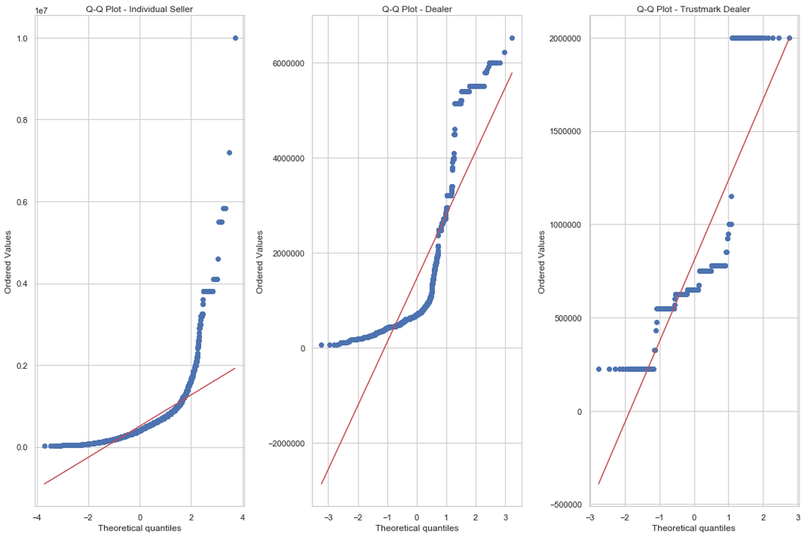

```python
# Q-Q plot for Individual Seller
plt.figure(figsize=(15,10))
plt.subplot(1, 3, 1)
stats.probplot(ind_prices, plot=plt)
plt.title('Q-Q Plot - Individual Seller')

# Q-Q plot for Dealer
plt.subplot(1, 3, 2)
stats.probplot(dealer_prices, plot=plt)
plt.title('Q-Q Plot - Dealer')

# Q-Q plot for Trustmark Dealer
plt.subplot(1, 3, 3)
stats.probplot(trustmark_prices, plot=plt)
plt.title('Q-Q Plot - Trustmark Dealer')
plt.tight_layout()
plt.show()
```

```python
# Testing for equal variance using Levene's Test

levene = stats.levene(ind_prices, dealer_prices, trustmark_prices)
print('Levene Test result')
print('tstatistic:', levene.statistic)
print('p-value:', levene.pvalue)

if levene.pvalue < 0.05:
    print('Reject the Null Hypothesis. Variances are not equal')
else:
    print('Failed to reject Null Hypothesis. Variances are equal')
```

```
Levene Test result
tstatistic: 559.6960652525559
p-value: 4.691645915322911e-228
Reject the Null Hypothesis. Variances are not equal
```

The Shapiro Wilk Test indicates that the data is not normally distributed since we are rejecting the null hypothesis for all the three seller types

[output not shown]

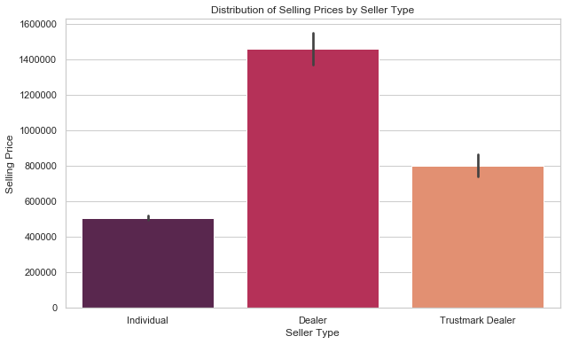

```python
# Performing Oneway ANOVA Test
t = stats.f_oneway(ind_prices,dealer_prices,trustmark_prices)
print('One-Way ANOVA Test:')
print("F-statistic:", result.statistic)
print("p-value:", result.pvalue)
mean_ind_prices = ind_prices.mean()
print('The mean selling price of Individual sellers:',mean_ind_prices)
mean_dealer_prices =  dealer_prices.mean()
print('The mean selling price of Dealers:',mean_dealer_prices)
mean_tdealer_prices = trustmark_prices.mean()
print('The mean selling price of Trustmark Dealer:',mean_tdealer_prices)
if result.pvalue < alpha:
    print("Reject the null hypothesis. There is a significant difference in the mean selling prices for different seller types.")
else:
    print("Failed to reject the null hypothesis. There is no significant difference in the mean selling prices for different seller types.")

plt.figure(figsize=(10, 6))
sns.barplot(x='seller_type', y='selling_price', data=df, palette='rocket')
plt.title("Distribution of Selling Prices by Seller Type")
plt.xlabel("Seller Type")
plt.ylabel("Selling Price")
plt.show()
```

The Shapiro Wilk test indicates that the data is not normally distributed. The Levene test infered that the variance are not equal. One way ANOVA test resulted that there is significant difference in the mean selling price between the seller types. Hence a non-parametric test - Kruskal Wallis is performed which will not assume the normality of the data.

### Framing hypothesis

H0: Medians of all the three seller type are same

H1: Medians of all the three seller types are different

```
Krushkal Test result
statistic value: 840.368353617212
pvalue: 3.2834516759547438e-183
Reject Null Hypothesis.
```

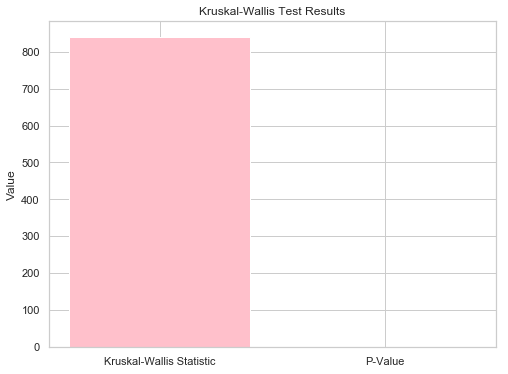

```python
# Performing Kruskal - Wallis Test

kw =tstatistics, pvalue = stats.kruskal(ind_prices, dealer_prices, trustmark_prices)
print('Krushkal Test result')
print('statistic value:', kw.statistic)
print('pvalue:', kw.pvalue)
if kw.pvalue < 0.05:
    print('Reject Null Hypothesis.')
else:
    print('Failed to reject Null Hypothesis.')

plt.figure(figsize=(8, 6))
plt.bar(['Kruskal-Wallis Statistic', 'P-Value'], [kw.statistic, kw.pvalue], color=['pink', 'green'])
plt.ylabel('Value')
plt.title('Kruskal-Wallis Test Results')
plt.show()
```

Based on Kruskal Wallis test result it is concluded that there is a significant difference in the Median of selling prices between the seller types

b) Based on the used car dataset, which transmission type is the most frequently used among the cars listed? Can we determine the proportion of each transmission type and identify the one that occurs most frequently? How does this information relate to potential buyers who may have a preference for a specific transmission type?

```python
#Transmission counts
trans = df['transmission'].value_counts()
print('Transmission type counts:')
print(trans)
```

```
Transmission type counts:
Manual       6865
Automatic    1041
Name: transmission, dtype: int64
```

```
Transmission proportion is:
Manual       0.868328
Automatic    0.131672
Name: transmission, dtype: float64
The most frequently used transmission is: Manual
```

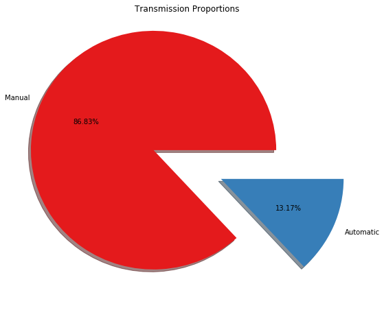

```python
##Transmission type that is used most frequently used among the cars and its proportions
trans = df['transmission'].value_counts(normalize=True)
print("Transmission proportion is:")

print(trans)

freq = trans.idxmax()
print("The most frequently used transmission is:", freq)

# using a pie-chart to identify the preference for a specific transmission type
plt.figure(figsize=(8, 8))
exploded=[0.3,0.3]
plt.pie(trans, labels=trans.index, autopct= '%.2f%%', explode=exploded, shadow=True, colors=sns.color_palette('Set1'))
plt.title("Transmission Proportions")
plt.show()
```

### Inference:

1. Manual is the most preferred transmission type which has 86.83% compared to Automatic which has 13.17%

c)How does the selling price of cars in the dataset vary with respect to factors such as the car's mileage, engine size, and year of manufacture? Can we visualize this relationship to gain insights into how these variables affect the selling price of a car?

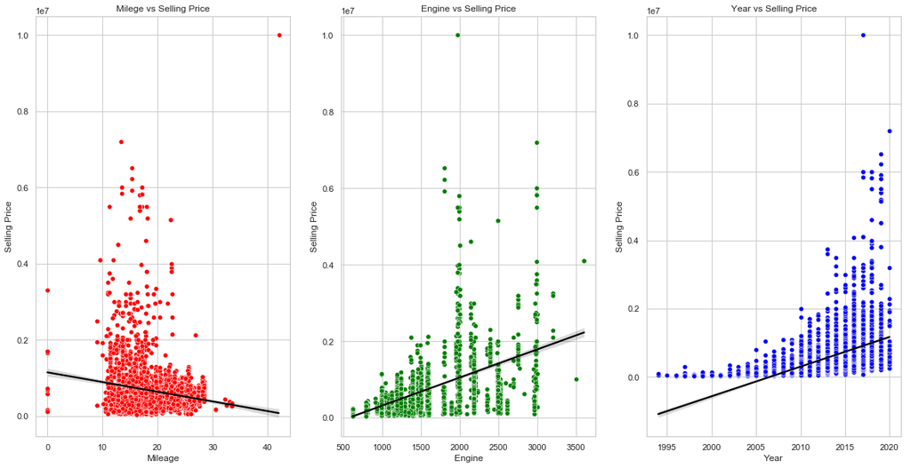

```python
# Using scatter plot for visualization of selling price with various factors
# 1. selling price vs mileage
plt.figure(figsize=(20,10))
plt.subplot(1,3,1)
sns.scatterplot(x='mileage', y='selling_price', data=df, color='red')
sns.regplot(x='mileage', y='selling_price', data=df, scatter=False, color='black')
plt.title('Milege vs Selling Price')
plt.xlabel('Mileage')
plt.ylabel('Selling Price')


#2. selling price vs engine size
plt.subplot(1,3,2)
sns.scatterplot(x='engine', y='selling_price', data=df, color='green')
sns.regplot(x='engine', y='selling_price', data=df, scatter=False, color='black')
plt.title('Engine vs Selling Price')
plt.xlabel('Engine')
plt.ylabel('Selling Price')

#3. year vs selling price

#2. selling price vs engine size
plt.subplot(1,3,3)
sns.scatterplot(x='year', y='selling_price', data=df, color='blue')
sns.regplot(x='year', y='selling_price', data=df, scatter=False, color='black')
plt.title('Year vs Selling Price')
plt.xlabel('Year')
plt.ylabel('Selling Price')
plt.show()
```

### Inference:

d) Does the covariance between the selling price of a used car and its mileage suggest a strong or weak relationship between the two variables? How does this covariance relate to potential buyers who may want to consider the mileage of a car when making purchasing decisions?

```python
covariance = df['selling_price'].cov(df['mileage'])
print("The covariance between Selling Price and Mileage is:", covariance)

correlation_coefficient = df['selling_price'].corr(df['mileage'])


print("Correlation Coefficient between Selling Price and Mileage:", correlation_coefficient)
```

```
The covariance between Selling Price and Mileage is: -414682.40536332334
Correlation Coefficient between Selling Price and Mileage: -0.12627994951355337
```

### Inference:

1. Covariance between selling price and mileage has weak negative relationship
2. Potential buyers may consider the fact that as mileage decrease price of the car increases.

e) If a car has a selling price of over $10,000, what is the probability that it has an automatic transmission?

```python
conversion_amt = 83
df['USDSellingPrice'] = df['selling_price']/conversion_amt
total_cars = df[df['USDSellingPrice']>10000].shape[0]
automatic_car = (df[(df['USDSellingPrice']>10000)&(df['transmission']=='Automatic')]).shape[0]
probability = automatic_car/total_cars
percent = probability*100

print("The probability that the car has an automatic transmission is:", round(percent,2), '%')
```

```
The probability that the car has an automatic transmission is: 49.11 %
```

### Q(2)

a) How does the median selling price of cars in the used car dataset vary across different fuel types and transmission types? Can we group the data by fuel type and transmission type and calculate the median selling price for each group?

```python
#Finding the median selling price of cars across different fuel and transmission types
m = df.groupby(['fuel', 'transmission'])['selling_price'].median().reset_index()
print("Median selling price of cars in the dataset across different fuel types and transmission types:")
m
```

```
Median selling price of cars in the dataset across different fuel types and transmission types:
```

|  | fuel | transmission | selling_price |
| --- | --- | --- | --- |
| 0 | CNG | Manual | 330000 |
| 1 | Diesel | Automatic | 2475000 |
| 2 | Diesel | Manual | 503000 |
| 3 | LPG | Manual | 200000 |
| 4 | Petrol | Automatic | 650000 |
| 5 | Petrol | Manual | 310000 |

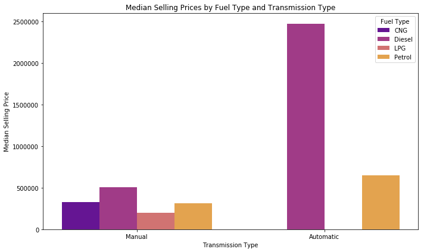

```python
plt.figure(figsize=(10, 6))
sns.barplot(x='transmission', y='selling_price', hue='fuel',data=m, palette='plasma')
plt.title("Median Selling Prices by Fuel Type and Transmission Type")
plt.xlabel("Transmission Type")
plt.ylabel("Median Selling Price")
plt.legend(title="Fuel Type")
plt.tight_layout()
plt.show()
```

### Inference:

1. Diesel is the fuel type has the highest median value of 2475000 for Automatic transmission.
2. Petrol has the highest median value of 650000 for Automatic Transmission.
3. Automatic transmission type doesn't have median values for CNG and LPG fuel type.
4. Manual transmission type has median values for all the fuel type.
5. Diesel is the highest fuel type in manual transmission that has a median value of 503000.
6. CNG and Petrol share a similar median value between 330000 - 310000

b) In the context of analyzing the used car market, can we determine if there is a significant difference in prices of cars based on the fuel type they use? This information can help buyers make informed decisions when purchasing a used car and may also inform government policies aimed at promoting the use of certain types of fuel in vehicles. (frame hypothesis and draw inferences)

```python
df.groupby('fuel')['selling_price'].describe()
```

| fuel | count | mean | std | min | 25% | 50% | 75% | max |
| --- | --- | --- | --- | --- | --- | --- | --- | --- |
| CNG | 52.0 | 317903.788462 | 101372.518867 | 120000.0 | 231250.0 | 330000.0 | 392250.0 | 545000.0 |
| Diesel | 4299.0 | 802450.282624 | 915753.684639 | 45000.0 | 350000.0 | 550000.0 | 800000.0 | 7200000.0 |
| LPG | 35.0 | 210885.714286 | 79828.039976 | 54000.0 | 150000.0 | 200000.0 | 275000.0 | 375000.0 |
| Petrol | 3520.0 | 472665.203125 | 631712.877861 | 29999.0 | 210000.0 | 350000.0 | 550000.0 | 10000000.0 |

### Framing Hypothesis

H0: There is no significant difference in the selling price of the car based on the fuel type.

h1: There is a significant difference in the selling price of the car based on the fuel type.

```python
#categorizing fuel type as CNG, Diesel, LPG, Petrol

cng = df[df['fuel']=='CNG']['selling_price']
diesel = df[df['fuel']=='Diesel']['selling_price']
lpg = df[df['fuel']=='LPG']['selling_price']
petrol = df[df['fuel']=='Petrol']['selling_price']

#performing shapiro wilk test for normality to identify if the fuel types are following normal distribution
CNG = stats.shapiro(cng)
print('Shapiro result for CNG')
print('tstatistic:',CNG.statistic)
print('pvalue:', CNG.pvalue)
if CNG.pvalue < 0.05:
    print('Reject the Null Hypothesis')
else:
    print('Failed to rejectt he Null Hypothesis')
```

```
Shapiro result for CNG
tstatistic: 0.9634802341461182
pvalue: 0.1107998862862587
Failed to rejectt he Null Hypothesis
```

```python
#performing shapiro wilk test for normality to identify if the fuel types are following normal distribution
DIESEL = stats.shapiro(diesel)
print('Shapiro result for DIESEL')
print('tstatistic:',DIESEL.statistic)
print('pvalue:', DIESEL.pvalue)
if DIESEL.pvalue < 0.05:
    print('Reject the Null Hypothesis')
else:
    print('Failed to rejectt he Null Hypothesis')
```

```
Shapiro result for DIESEL
tstatistic: 0.5905802845954895
pvalue: 0.0
Reject the Null Hypothesis
```

```python
#performing shapiro wilk test for normality to identify if the fuel types are following normal distribution
LPG = stats.shapiro(lpg)
print('Shapiro result for LPG')
print('tstatistic:',LPG.statistic)
print('pvalue:', LPG.pvalue)
if LPG.pvalue < 0.05:
    print('Reject the Null Hypothesis')
else:
    print('Failed to rejectt he Null Hypothesis')
```

```
Shapiro result for LPG
tstatistic: 0.9675600528717041
pvalue: 0.3798154294490814
Failed to rejectt he Null Hypothesis
```

```python
#performing shapiro wilk test for normality to identify if the fuel types are following normal distribution
PETROL = stats.shapiro(petrol)
print('Shapiro result for PETROL')
print('tstatistic:',PETROL.statistic)
print('pvalue:', PETROL.pvalue)
if PETROL.pvalue < 0.05:
    print('Reject the Null Hypothesis')
else:
    print('Failed to rejectt he Null Hypothesis')
```

```
Shapiro result for PETROL
tstatistic: 0.43488073348999023
pvalue: 0.0
Reject the Null Hypothesis
```

[figure not shown]

```python
# Q-Q plot for CNG
plt.figure(figsize=(15,4))
plt.subplot(1, 4, 1)
stats.probplot(ind_prices, plot=plt)
plt.title('Q-Q Plot - CNG')

# Q-Q plot for DIESEL
plt.subplot(1, 4, 2)
stats.probplot(dealer_prices, plot=plt)
plt.title('Q-Q Plot - DIESEL')

# Q-Q plot for LPG
plt.subplot(1, 4, 3)
stats.probplot(trustmark_prices, plot=plt)
plt.title('Q-Q Plot - LPG')
plt.tight_layout()

# Q-Q plot for PETROL
plt.subplot(1, 4, 4)
stats.probplot(trustmark_prices, plot=plt)
plt.title('Q-Q Plot - PETROL')
plt.tight_layout()
plt.show()
```

```python
# Testing for equal variance using Levene's Test

levene = stats.levene(cng,diesel,lpg,petrol)
print('Levene Test result')
print('tstatistic:', levene.statistic)
print('p-value:', levene.pvalue)

if levene.pvalue < 0.05:
    print('Reject the Null Hypothesis. Variances are not equal')
else:
    print('Failed to reject Null Hypothesis. Variances are equal')
```

```
Levene Test result
tstatistic: 48.945864420404206
p-value: 2.463675999346852e-31
Reject the Null Hypothesis. Variances are not equal
```

```python
#performing oneway ANOVA Test
print('One-Way ANOVA Test:')
result=stats.f_oneway(cng,diesel,lpg,petrol)
print("f-statistic:",result.statistic)
print("p-Value:",result.pvalue)

#inferences  --declaring 0.05 as the alpha.
if (result.pvalue < 0.05):
    print("Reject the null hypothesis. There is a significant difference in the selling price of the car based on the fuel type.")
else:
    print("Failed to reject the null hypothesis. There is no significant difference in the selling price of the car based on the fuel type.")
```

```
One-Way ANOVA Test:
f-statistic: 117.30554435257851
p-Value: 2.52340474514499e-74
Reject the null hypothesis. There is a significant difference in the selling price of the car based on the fuel type.
```

```python
# performing kruskal wallis test

kw= stats.kruskal(cng, diesel, lpg, petrol)

print("Kruskal-Wallis Test:")
print("Kruskal-Wallis statistic:", kw.statistic)
print("p-value:", kw.pvalue)

if kw.pvalue < 0.05:
    print("Reject the null hypothesis")
else:
    print("Failed to reject the null hypothesis.")
```

```
Kruskal-Wallis Test:
Kruskal-Wallis statistic: 892.8076695571675
p-value: 3.214271037253098e-193
Reject the null hypothesis
```

Based on the inference drawn

Potential buyers needs to consider the fact that the selling price of the car increases based on the fuel type.

### Q(3)

a) In the used car dataset, there are some mileage values that are represented in units other than miles, such as kilometers. Convert these values into miles and check the mileage distribution. (Note: Convert mileage in kilometers to miles by multiplying by 0.621371.)

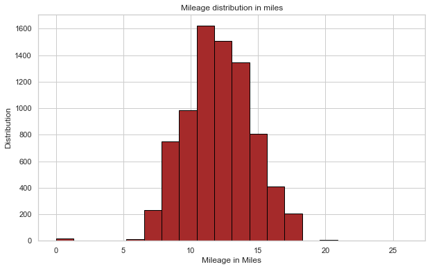

```python
df['mileage in miles'] = df['mileage'].apply(lambda x:x*0.621371)
plt.figure(figsize=(10,6))
plt.hist(df['mileage in miles'], bins=20, color = 'brown', edgecolor='black')
plt.title('Mileage distribution in miles')
plt.xlabel('Mileage in Miles')
plt.ylabel('Distribution')
plt.show()
```

```python
df.head()
```

|  | Sales_ID | name | year | selling_price | km_driven | fuel | seller_type | transmission | owner | mileage | engine | max_power | seats | City | Postal_code | Sales_status | mileage in miles |
| --- | --- | --- | --- | --- | --- | --- | --- | --- | --- | --- | --- | --- | --- | --- | --- | --- | --- |
| 0 | 1 | Maruti Swift Dzire VDI | 2014 | 450000 | 145500 | Diesel | Individual | Manual | First Owner | 23.40 | 1248.0 | 74.00 | 5 | Mumbai | 400001 | Y | 14.540081 |
| 1 | 2 | Skoda Rapid 1.5 TDI Ambition | 2014 | 370000 | 120000 | Diesel | Individual | Manual | Second Owner | 21.14 | 1498.0 | 103.52 | 5 | Ranchi | 834008 | Y | 13.135783 |
| 2 | 3 | Honda City 2017-2020 EXi | 2006 | 158000 | 140000 | Petrol | Individual | Manual | Third Owner | 17.70 | 1497.0 | 78.00 | 5 | Noida | 201301 | Y | 10.998267 |
| 3 | 4 | Hyundai i20 Sportz Diesel | 2010 | 225000 | 127000 | Diesel | Individual | Manual | First Owner | 23.00 | 1396.0 | 90.00 | 5 | Dehradun | 248141 | Y | 14.291533 |
| 4 | 5 | Maruti Swift VXI BSIII | 2007 | 130000 | 120000 | Petrol | Individual | Manual | First Owner | 16.10 | 1298.0 | 88.20 | 5 | Chennai | 600020 | Y | 10.004073 |

### Inference:

1. Based on the histogram, majority of the cars have Mileage values between 6 miles to 19 miles.
2. The central tendency occurs in the mileage values 10.5-11 which has the highest distribution of around 1500.
3. There are some outliers in 0 miles which indicates that few cars have a relatively low mileage.

b) You are a data analyst working for a car dealership company. Investigate whether there is a statistically significant difference in the distribution of the number of seats between cars with automatic and manual transmissions. Perform a hypothesis test to determine whether there is a significant difference in the number of seats for cars with automatic and manual transmissions. Note: Use appropriate test to check if there is a significant difference in the means of the number of seats for the two groups. Determine the appropriate assumptions for the test and verify if they are satisfied. Calculate the test statistic and p-value to determine if there is a statistically significant difference between the two groups. Based on your analysis, provide insights to the management team about whether the number of seats is significantly different between cars with automatic and manual transmissions. This information will be useful in identifying which transmission type is more popular among customers and which features customers value the most. It will also help the company make informed decisions on inventory management and pricing strategies.

```python
automatic = df[df['transmission'] == 'Automatic']['seats']
manual = df[df['transmission'] == 'Manual']['seats']

# performing the two-sample t-test
t_statistic, p_value = stats.ttest_ind(automatic, manual)
print("Two-Sample T-Test:")
print(f"T-Statistic: {t_statistic}")
print(f"P-Value: {p_value}")



# inferences: -- 0.05 is set as alpha
if p_value < 0.05:
    print("Reject the null hypothesis. There is a significant difference in the number of seats based on the transmission type.")
else:
    print("Fail to reject the null hypothesis. There is no significant difference in the number of seats based on the transmission type.")
```

```
Two-Sample T-Test:
T-Statistic: -6.482469584385466
P-Value: 9.564849249329684e-11
Reject the null hypothesis. There is a significant difference in the number of seats based on the transmission type.
```

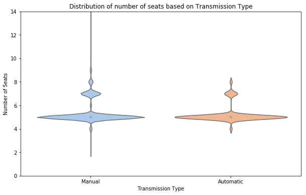

```python
#visualizing using violin plot

plt.figure(figsize=(10,6))
sns.violinplot(x=df['transmission'], y=df['seats'] ,palette='pastel')
plt.title("Distribution of number of seats based on Transmission Type")
plt.xlabel("Transmission Type")
plt.ylabel("Number of Seats")
plt.ylim(0, max(df['seats']))  # Set y-axis limit
plt.show()
```

### Inference:

1. Based on the t-statistic and p-value null hypothesis is rejected which concludes that there is significant difference in the number of seats based on the transmission type.
2. Cars with manual transmission tends to have more number of seats when compared to cars with automatic transmission.

### Q(4)

a) Create a stacked histogram to analyze the distribution of mileage for cars based on their fuel type and transmission.

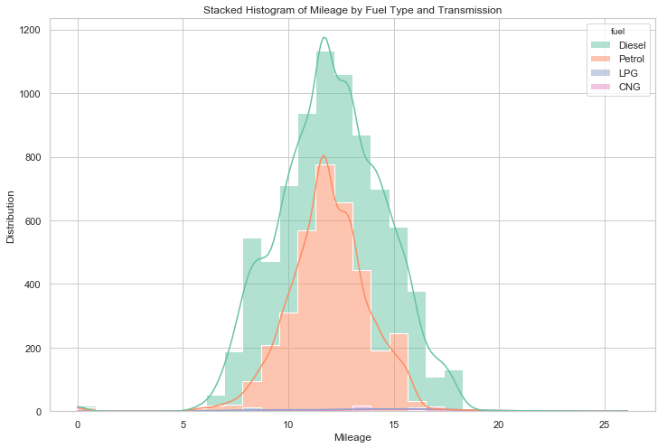

```python
plt.figure(figsize=(12, 8))
sns.histplot(data=df, x='mileage in miles', hue='fuel', multiple='stack', element='step', kde=True, bins=30, palette='Set2')
plt.title("Stacked Histogram of Mileage by Fuel Type and Transmission")
plt.xlabel("Mileage")
plt.ylabel("Distribution")
plt.show()
```

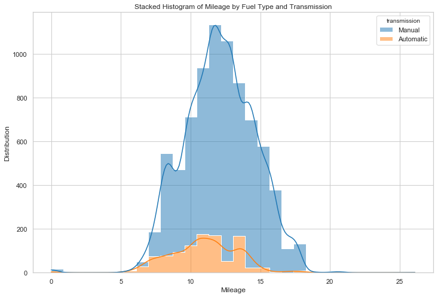

```python
plt.figure(figsize=(12, 8))
sns.histplot(data=df, x='mileage in miles', hue='transmission', multiple='stack', element='step', kde=True, bins=30, palette='tab10')
plt.title("Stacked Histogram of Mileage by Fuel Type and Transmission")
plt.xlabel("Mileage")
plt.ylabel("Distribution")
plt.show()
```

```python
# Group by fuel type and transmission and calculate summary statistics
summary_stats = df.groupby(['fuel', 'transmission'])['mileage'].agg(['mean', 'median', 'std'])

print("Summary Statistics of Mileage by Fuel Type and Transmission:")
summary_stats
```

```
Summary Statistics of Mileage by Fuel Type and Transmission:
```

[output not shown]

b) As a data analyst in a car dealership company, you are analyzing the company's sales data to identify any significant differences in the selling prices of cars based on the fuel type. If there is a statistically significant difference in the selling price distribution for different fuel types, which fuel types have the highest and lowest selling prices? Your task is to perform an analysis of the data and report your findings to the management. Based on your analysis, you will be able to provide insights on which fuel types are most popular among customers and which models are more expensive, helping the company make informed decisions on inventory and pricing strategies. Note: Use an appropriate test to determine if there is a statistically significant difference in the selling price distribution for different fuel types. And further determine which fuel types have the highest and lowest selling prices.

```python
mean_prices = df.groupby('fuel')['selling_price'].mean()
mean_prices
```

```
fuel
CNG       317903.788462
Diesel    802450.282624
LPG       210885.714286
Petrol    472665.203125
Name: selling_price, dtype: float64
```

```
One-Way ANOVA Test:
f-statistic: 117.30554435257851
p-Value: 2.52340474514499e-74
Reject the null hypothesis. There is a significant difference in the selling price of the car based on the fuel type.
The fuel type with the highest selling price is Diesel with Selling Price 802450.282623866
The fuel type with the lowest selling price is LPG with Selling Price 210885.7142857143
```

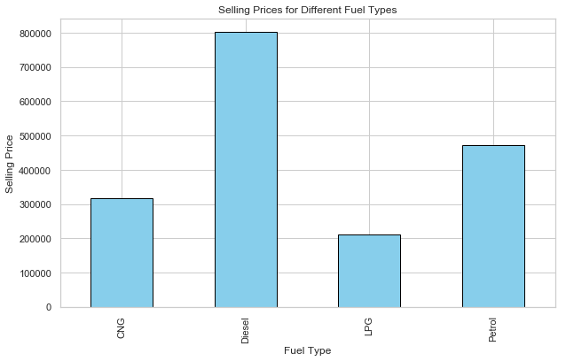

```python
#categorizing fuel type as CNG, Diesel, LPG, Petrol

cng = df[df['fuel']=='CNG']['selling_price']
diesel = df[df['fuel']=='Diesel']['selling_price']
lpg = df[df['fuel']=='LPG']['selling_price']
petrol = df[df['fuel']=='Petrol']['selling_price']

#performing oneway ANOVA Test
print('One-Way ANOVA Test:')
result=stats.f_oneway(cng,diesel,lpg,petrol)
print("f-statistic:",result.statistic)
print("p-Value:",result.pvalue)

#inferences  --declaring 0.05 as the alpha.
if (result.pvalue < 0.05):
    print("Reject the null hypothesis. There is a significant difference in the selling price of the car based on the fuel type.")
else:
    print("Failed to reject the null hypothesis. There is no significant difference in the selling price of the car based on the fuel type.")

# identifying which fuel type has highest and lowest selling price
high_sp = mean_prices.idxmax()
low_sp = mean_prices.idxmin()

print("The fuel type with the highest selling price is", high_sp, "with Selling Price", mean_prices['Diesel'])
print("The fuel type with the lowest selling price is", low_sp, "with Selling Price", mean_prices['LPG'])

#Visualizing the output using a barplot
plt.figure(figsize=(10, 6))
mean_prices.plot(kind='bar', color='skyblue', edgecolor='black')
plt.title("Selling Prices for Different Fuel Types")
plt.xlabel("Fuel Type")
plt.ylabel("Selling Price")
plt.show()
```

### Inference:

1. Diesel is the most popular fuel type with almost 802450.282623866 selling price and is also quite expensive compared to other fuel types.
2. Petrol is the second most popular fuel type with almost 472665.203125 selling price.
3. LPG is considered to be the fuel type which has low selling price of 210885.714286.

## Q(5)

a) How many cars are there in each make and model category in the used car dataset? Can we provide a distribution of the cars based on their make and model?

```python
cars = df.groupby(['name', 'year'])['Sales_ID'].count()
cars
```

```
name                                            year
Ambassador CLASSIC 1500 DSL AC                  2000     1
Ambassador Classic 2000 DSZ AC PS               1994     1
Ambassador Grand 1500 DSZ BSIII                 2008     1
Ambassador Grand 2000 DSZ PW CL                 2008     1
Ashok Leyland Stile LE                          2013     1
Audi A3 35 TDI Premium Plus                     2017     1
                                                2018     1
Audi A3 40 TFSI Premium                         2017     1
Audi A4 1.8 TFSI                                2010     1
Audi A4 2.0 TDI                                 2014     2
Audi A4 2.0 TDI 177 Bhp Premium Plus            2013     1
Audi A4 35 TDI Premium Plus                     2015     1
                                                2016     2
                                                2018     1
Audi A6 2.0 TDI                                 2014     1
Audi A6 2.0 TDI  Design Edition                 2013     1
Audi A6 2.0 TDI Premium Plus                    2013     1
Audi A6 2.0 TDI Technology                      2013     1
Audi A6 35 TFSI Matrix                          2019     3
Audi Q3 2.0 TDI Quattro Premium Plus            2014     1
                                                2016     1
                                                2017     2
Audi Q3 35 TDI Quattro Premium Plus             2018     1
Audi Q3 35 TDI Quattro Technology               2018     1
Audi Q5 2.0 TDI                                 2011     1
Audi Q5 3.0 TDI Quattro                         2014     2
Audi Q5 35TDI Premium Plus                      2018     6
Audi Q5 45 TDI quattro Technology               2015     1
Audi Q7 3.0 TDI Quattro                         2009     2
                                                2010     1
                                                        ..
Volkswagen Vento 1.5 TDI Highline               2017     1
Volkswagen Vento 1.5 TDI Highline AT            2014     2
                                                2016     2
Volkswagen Vento 1.5 TDI Highline BSIV          2019     1
Volkswagen Vento 1.5 TDI Highline Plus AT       2015     1
Volkswagen Vento 1.5 TDI Highline Plus AT BSIV  2018     1
Volkswagen Vento 1.6 Highline                   2014     3
Volkswagen Vento Diesel Breeze                  2012     1
```

[output cut: 8 more lines]

```
Volkswagen Vento Konekt Diesel Highline         2014     1
Volkswagen Vento Petrol Highline                2011     1
                                                2012     2
Volkswagen Vento Petrol Highline AT             2011     1
Volkswagen Vento Petrol Trendline               2011     1
Volvo S60 D4 SUMMUM                             2014     1
                                                2016     1
Volvo S90 D4 Inscription BSIV                   2019     1
Volvo V40 Cross Country D3                      2013     1
Volvo V40 D3 R-Design                           2018    29
Volvo XC40 D4 Inscription BSIV                  2019    30
Volvo XC40 D4 R-Design                          2018     2
Volvo XC60 Inscription D5 BSIV                  2018     1
Volvo XC90 T8 Excellence BSIV                   2017     1
Name: Sales_ID, Length: 3699, dtype: int64
```

b) Does the distribution of car models vary significantly across different owner types in the used car dataset? Note: Use appropriate test to determine if there is a significant relationship between car models and owner types.

### Framing Hypothesis:

H1: Distribution of car models does not vary significantly across different owners

```python
# performing chi-squared test

table=pd.crosstab(df['name'], df['owner'])
chi_stat, p_val, dof, exp_values = stats.chi2_contingency(table)
print("Chi-Squared:", chi_stat)
print("P-Value:", p_value)

if p_value < 0.05:
    print("Distribution of car models vary significantly across different owners.")
else:
    print("Distribution of car models does not vary significantly across different owners.")
```

[output not shown]